# Geospatial Visualization with R

——Email: ozkul.vedat@stud.hs-fresenius.de—— Matriculation Number: 401136761

Vedat Erdem Özkul

Hochschule Fresenius

2026-02-06

## Why Geospatial Visualization Matters

- Understand spatial patterns
- Support decision-making
- Explore relationships between places
- Transform data into visual insight

## What is Geospatial Data?

Geospatial data is information linked to a location.

Examples:

- Roads
- Buildings
- Cities
- Countries
- Rivers

## Vector vs Raster Data

| Vector | Raster |
| --- | --- |
| Points | Cells |
| Lines | Pixels |
| Polygons | Continuous surfaces |
| Roads | Elevation |
| Buildings | Temperature |

## Layer Concept

A map is built from multiple layers.

Examples:

- Country boundaries
- Cities
- Roads
- Population

Layers can be combined to answer spatial questions.

## Why Use R?

R provides:

- Reproducible workflows
- Data transformation
- Visualization
- Spatial analysis
- Open-source tools

## Packages

```r
library(sf)
library(tidyverse)
library(ggplot2)
library(rnaturalearth)
library(rnaturalearthdata)
```

## Load Spatial Data

```r
world <- ne_countries(
  scale = "medium",
  returnclass = "sf"
)

germany <- world |>
  filter(admin == "Germany")
```

[output not shown]

## Coordinate Reference System

```r
st_crs(germany)
```

```
Coordinate Reference System:
  User input: WGS 84
  wkt:
GEOGCRS["WGS 84",
    DATUM["World Geodetic System 1984",
        ELLIPSOID["WGS 84",6378137,298.257223563,
            LENGTHUNIT["metre",1]]],
    PRIMEM["Greenwich",0,
        ANGLEUNIT["degree",0.0174532925199433]],
    CS[ellipsoidal,2],
        AXIS["latitude",north,
            ORDER[1],
            ANGLEUNIT["degree",0.0174532925199433]],
        AXIS["longitude",east,
            ORDER[2],
            ANGLEUNIT["degree",0.0174532925199433]],
    ID["EPSG",4326]]
```

## Basic Vector Map

```r
ggplot() +
  geom_sf(
    data = germany,
    fill = "grey90",
    color = "black"
  ) +
  theme_minimal()
```

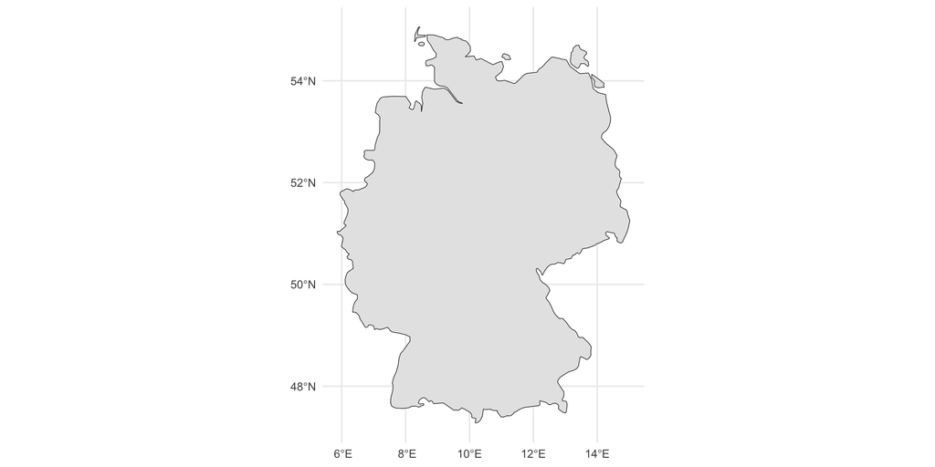

## A Question You Should Have Asked

Before creating a map:

“How do we know what is inside this dataset?”

We should never use a dataset blindly.

## Useful functions:

names(xxxx)

glimpse(xxxx)

These functions help us discover:

- available variables
- data types
- relevant columns
- possible filters

Only then we can decide what to visualize.

## In-Class Activity: Mapping German Cities

In this activity, we will build a map step by step.

Goal:

- add city points
- combine spatial layers
- filter cities by population
- interpret the result

## Activity Step 1: Add Cities

```r
cities <- ne_download(
  scale = 10,
  type = "populated_places",
  category = "cultural",
  returnclass = "sf"
)

germany_cities <- cities |>
  filter(ADM0NAME == "Germany")
```

[output not shown]

## Activity Step 2: Combine Spatial Layers

```r
ggplot() +
  geom_sf(
    data = germany,
    fill = "grey95",
    color = "black"
  ) +
  geom_sf(
    data = germany_cities,
    size = 0.8,
    alpha = 0.5
  ) +
  theme_minimal()
```

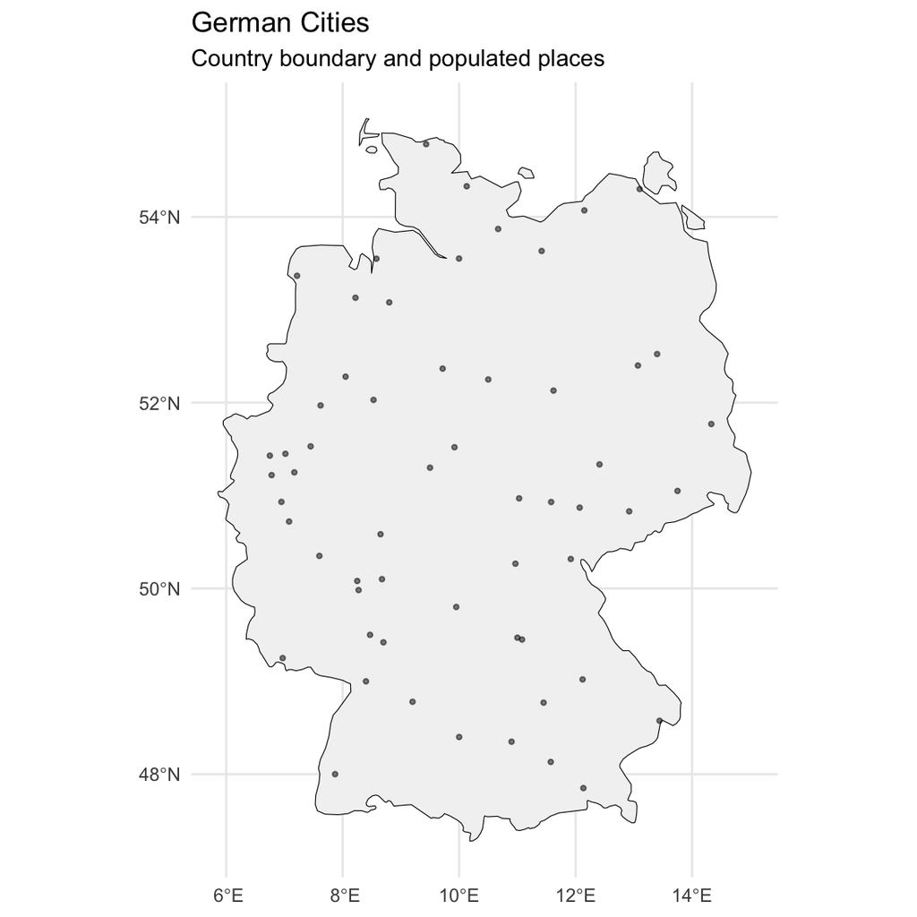

## Activity Step 3: Filter the Dataset

```r
germany_cities_major <- germany_cities |>
  filter(POP_MAX > 500000)

ggplot() +
  geom_sf(
    data = germany,
    fill = "grey95",
    color = "black"
  ) +
  geom_sf(
    data = germany_cities_major,
    size = 2
  ) +
  theme_minimal()
```

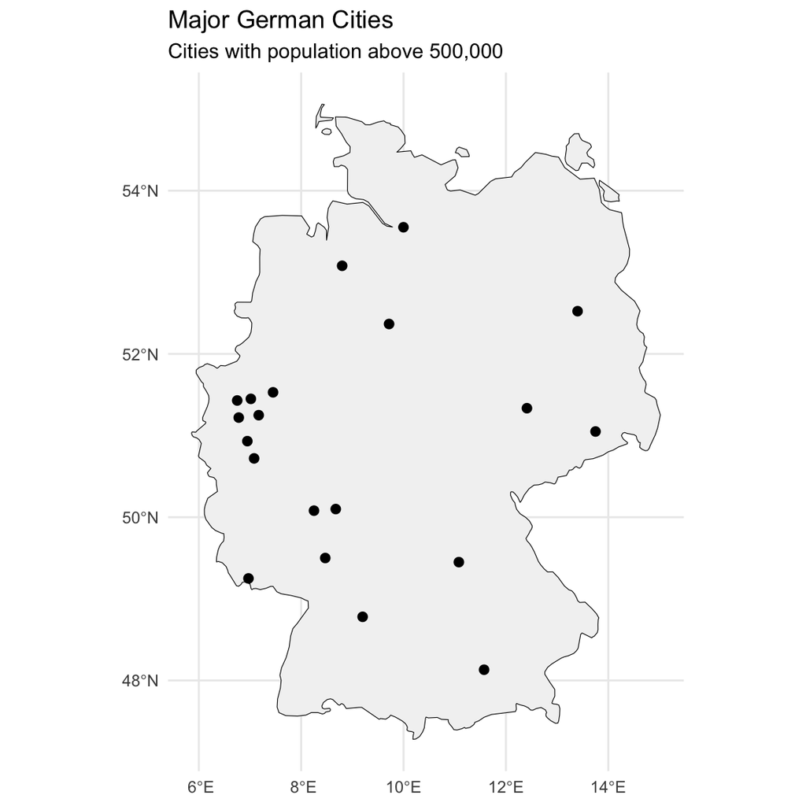

## Activity Step 4: Interpret the Map

Discussion questions:

- What changed after filtering?
- Why is filtering useful before visualization?
- Which cities remain visible?
- How can this support decision-making?

## Key Takeaways

- Geospatial data connects information to location.
- Vector and raster data serve different purposes.
- Layers can be combined.
- R provides reproducible geospatial workflows.

## References

Lovelace, R., Nowosad, J., & Muenchow, J. (2019). *Geocomputation with R*.

Pebesma, E., & Bivand, R. (2023). *Spatial Data Science with Applications in R*.

Huber, S. (n.d.). *How to Use R for Data Science*.

## Questions?

Thank you.